# Neural Network Project

# Part B

#### Goal Statement

We have been provided image data and labels. We need to build NN model to predict images with high accuracy, recall and precision.

## Q.1.Data Import and Exploration

### Q.1.A. Read the .h5 file and assign to a variable.

```python
# file_path = '/content/drive/MyDrive/Colab/Autonomous_Vehicles_SVHN_single_grey1.h5'
file_path = 'Autonomous_Vehicles_SVHN_single_grey1.h5'
df2 = h5py.File(file_path, 'r')
```

### Q.1.B.Print all the keys from the .h5 file

```python
print("Keys: %s" % df2.keys())
for key in df2.keys():
        print(key)
```

```
Keys: <KeysViewHDF5 ['X_test', 'X_train', 'X_val', 'y_test', 'y_train', 'y_val']>
X_test
X_train
X_val
y_test
y_train
y_val
```

### Q.1.C. Split the data into X_train, X_test, Y_train, Y_test

As we can see data is already in split format with respective keys and we just need to fetch data for respective variables

```python
# Open the HDF5 file and read data into a DataFrame
X_trainB = df2['X_train'][:]
y_trainB = df2['y_train'][:]
X_valB = df2['X_val'][:]
y_valB = df2['y_val'][:]
X_testB = df2['X_test'][:]
y_testB = df2['y_test'][:]

XB = np.concatenate((X_trainB,X_valB , X_testB), axis=0)
yB = np.concatenate((y_trainB,y_valB, y_testB), axis=0)
```

### Q.2. Data Visualisation and preprocessing

### Q.2.A. Print shape of all the 4 data split into x, y, train, test to verify if x & y is in sync

```python
print("X shape:", XB.shape)
print("y shape:", yB.shape)
print("X_train shape:", X_trainB.shape)
print("y_train shape:", y_trainB.shape)
print("X_val shape:", X_valB.shape)
print("y_val shape:", y_valB.shape)
print("X_test shape:", X_testB.shape)
print("y_test shape:", y_testB.shape)
```

```
X shape: (120000, 32, 32)
y shape: (120000,)
X_train shape: (42000, 32, 32)
y_train shape: (42000,)
X_val shape: (60000, 32, 32)
y_val shape: (60000,)
X_test shape: (18000, 32, 32)
y_test shape: (18000,)
```

2nd and third dimension values for all X, X_train, y_train are matching. Also row count for X and y, X_train and y_train, X_test and y_test are matching. Hence it can be concluded that X, y variables for training and testing are in sync.

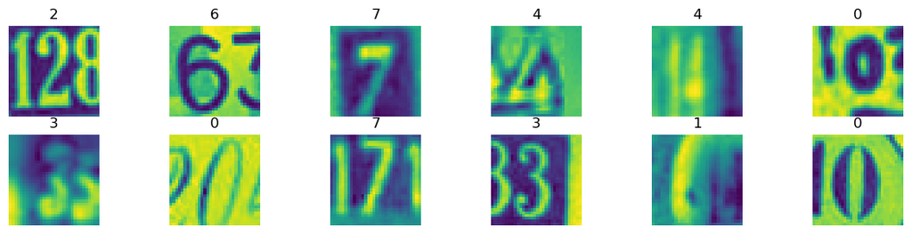

```python
# prompt: Visualise first 10 images in train data and print its corresponding labels

plt.figure(figsize=(14, 3))
for i in range(12):
    plt.subplot(2, 6, i + 1)
    plt.imshow(X_trainB[i])
    plt.axis('off')
    plt.title(y_trainB[i], fontsize=12)
plt.show()
```

### Q.2.C. Reshape all the images with appropriate shape update the data in same variable.

```python
X_trainBr = X_trainB.reshape((X_trainB.shape[0], -1))
X_testBr = X_testB.reshape((X_testB.shape[0], -1))
X_valBr = X_valB.reshape((X_valB.shape[0], -1))

# Print shapes of the merged datasets after reshaping
print("\nshapes after reshaping:")
print("X_train shape:", X_trainBr.shape)
print("y_train shape:", y_trainB.shape)

print("X_test shape:", X_testBr.shape)
print("y_test shape:", y_testB.shape)

print("X_val shape:", X_valBr.shape)
print("y_val shape:", y_valB.shape)
```

```
shapes after reshaping:
X_train shape: (42000, 1024)
y_train shape: (42000,)
X_test shape: (18000, 1024)
y_test shape: (18000,)
X_val shape: (60000, 1024)
y_val shape: (60000,)
```

### Q.2.D. Normalize the images i.e. Normalise the pixel values

Normalization involves rescaling the pixel values to a range of 0 to 1. This is achieved by dividing each pixel value by 255.0. For example, a pixel value of 0 becomes 0/255.0 = 0.0, and a pixel value of 255 becomes 255/255.0 = 1.0.

```python
X_train_normalizedB = X_trainBr / 255.0
X_test_normalizedB = X_testBr / 255.0
X_val_normalizedB = X_valBr / 255.0
```

### Q.2.E. Transform Labels into format acceptable by Neural Network

```python
unique_values = np.unique(yB)
print("Unique values in y_train:", unique_values)
num_classes = len(np.unique(yB))
```

```
Unique values in y_train: [0 1 2 3 4 5 6 7 8 9]
```

```python
y_train_categoricalB = to_categorical(y_trainB, num_classes=num_classes)
y_test_categoricalB = to_categorical(y_testB, num_classes=num_classes)
y_val_categoricalB = to_categorical(y_valB, num_classes=num_classes)
```

### Q.2.F. Print total Number of classes in the Dataset

```python
num_classes = len(np.unique(yB))
print("Total number of classes in the dataset:", num_classes)
unique_values = np.unique(yB)
print("Unique values in dataset:", unique_values)
```

```
Total number of classes in the dataset: 10
Unique values in dataset: [0 1 2 3 4 5 6 7 8 9]
```

## Q.3. Model Training & Evaluation using Neural Network

### Q.3.A. Design a Neural Network to train a classifier

##### model_B1

activation=LeakyReLU/softmax 4 layers : neurons=[512, 256, 128,64] learning_rate=0.001 dropout_rate=No batch_norm=True epochs=50 batch_size=32

```python
#Lets design model with 4 layers
input_shape = (1024,)  # The shape of each input sample
# Define the input layer
inputs = Input(shape=input_shape)
x = Dense(512, kernel_initializer='he_uniform')(inputs)  # First hidden layer with 512 neurons
x = LeakyReLU()(x)
x = BatchNormalization()(x)  # Add BatchNormalization
  # Add Dropout for regularization

x = Dense(256, kernel_initializer='he_uniform')(x)  # Next hidden layer
x = LeakyReLU()(x)
x = BatchNormalization()(x)


x = Dense(128, kernel_initializer='he_uniform')(x)  # Next hidden layer
x = LeakyReLU()(x)
x = BatchNormalization()(x)

x = Dense(64, kernel_initializer='he_uniform')(x)  # Next hidden layer
x = LeakyReLU()(x)
x = BatchNormalization()(x)

outputs = Dense(10, activation='softmax', kernel_initializer='he_uniform')(x)  # Output layer for 10 classes

# Create the model
model_B1 = Model(inputs=inputs, outputs=outputs)
#Lets print model design
model_B1.summary()
```

```
Model: "functional_47"
```

```
┏━━━━━━━━━━━━━━━━━━━━━━━━━━━━━━━━━━━━━━┳━━━━━━━━━━━━━━━━━━━━━━━━━━━━━┳━━━━━━━━━━━━━━━━━┓
┃ Layer (type)                         ┃ Output Shape                ┃         Param # ┃
┡━━━━━━━━━━━━━━━━━━━━━━━━━━━━━━━━━━━━━━╇━━━━━━━━━━━━━━━━━━━━━━━━━━━━━╇━━━━━━━━━━━━━━━━━┩
│ input_layer_7 (InputLayer)           │ (None, 1024)                │               0 │
├──────────────────────────────────────┼─────────────────────────────┼─────────────────┤
│ dense_35 (Dense)                     │ (None, 512)                 │         524,800 │
├──────────────────────────────────────┼─────────────────────────────┼─────────────────┤
│ leaky_re_lu_21 (LeakyReLU)           │ (None, 512)                 │               0 │
├──────────────────────────────────────┼─────────────────────────────┼─────────────────┤
│ batch_normalization_25               │ (None, 512)                 │           2,048 │
│ (BatchNormalization)                 │                             │                 │
├──────────────────────────────────────┼─────────────────────────────┼─────────────────┤
│ dense_36 (Dense)                     │ (None, 256)                 │         131,328 │
├──────────────────────────────────────┼─────────────────────────────┼─────────────────┤
│ leaky_re_lu_22 (LeakyReLU)           │ (None, 256)                 │               0 │
├──────────────────────────────────────┼─────────────────────────────┼─────────────────┤
│ batch_normalization_26               │ (None, 256)                 │           1,024 │
│ (BatchNormalization)                 │                             │                 │
├──────────────────────────────────────┼─────────────────────────────┼─────────────────┤
│ dense_37 (Dense)                     │ (None, 128)                 │          32,896 │
├──────────────────────────────────────┼─────────────────────────────┼─────────────────┤
│ leaky_re_lu_23 (LeakyReLU)           │ (None, 128)                 │               0 │
├──────────────────────────────────────┼─────────────────────────────┼─────────────────┤
│ batch_normalization_27               │ (None, 128)                 │             512 │
│ (BatchNormalization)                 │                             │                 │
├──────────────────────────────────────┼─────────────────────────────┼─────────────────┤
│ dense_38 (Dense)                     │ (None, 64)                  │           8,256 │
├──────────────────────────────────────┼─────────────────────────────┼─────────────────┤
│ leaky_re_lu_24 (LeakyReLU)           │ (None, 64)                  │               0 │
├──────────────────────────────────────┼─────────────────────────────┼─────────────────┤
│ batch_normalization_28               │ (None, 64)                  │             256 │
│ (BatchNormalization)                 │                             │                 │
├──────────────────────────────────────┼─────────────────────────────┼─────────────────┤
│ dense_39 (Dense)                     │ (None, 10)                  │             650 │
└──────────────────────────────────────┴─────────────────────────────┴─────────────────┘
```

```
 Total params: 701,770 (2.68 MB)
```

```
 Trainable params: 699,850 (2.67 MB)
```

```
 Non-trainable params: 1,920 (7.50 KB)
```

### Q.3.B. Train the classifier using previously designed Architecture (Use best suitable parameters)

We will use below parameters

optimizer=Adam learning_rate=0.001 batch_size=32 epochs=50,

```python
# Compile the model with Adam optimizer and learning rate scheduling
optimizer = Adam(learning_rate=0.001)
# optimizer = RMSprop(learning_rate=0.001)
model_B1.compile(optimizer=optimizer, loss='categorical_crossentropy', metrics=['accuracy'])

# Define early stopping to prevent overfitting
early_stopping = EarlyStopping(monitor='val_loss', patience=5, restore_best_weights=True)
# Train the model with early stopping
historyB1 = model_B1.fit(X_train_normalizedB, y_train_categoricalB, batch_size=32, epochs=50,
                    validation_data=(X_val_normalizedB, y_val_categoricalB), callbacks=[early_stopping])
```

```
1313/1313 ━━━━━━━━━━━━━━━━━━━━ 33s 17ms/step - accuracy: 0.4121 - loss: 1.7392 - val_accuracy: 0.5145 - val_loss: 1.4794
1313/1313 ━━━━━━━━━━━━━━━━━━━━ 21s 16ms/step - accuracy: 0.6476 - loss: 1.1076 - val_accuracy: 0.6424 - val_loss: 1.0955
1313/1313 ━━━━━━━━━━━━━━━━━━━━ 22s 17ms/step - accuracy: 0.6980 - loss: 0.9549 - val_accuracy: 0.6712 - val_loss: 1.0296
1313/1313 ━━━━━━━━━━━━━━━━━━━━ 22s 16ms/step - accuracy: 0.7223 - loss: 0.8862 - val_accuracy: 0.6571 - val_loss: 1.0642
1313/1313 ━━━━━━━━━━━━━━━━━━━━ 22s 16ms/step - accuracy: 0.7380 - loss: 0.8411 - val_accuracy: 0.7392 - val_loss: 0.8354
1313/1313 ━━━━━━━━━━━━━━━━━━━━ 22s 17ms/step - accuracy: 0.7526 - loss: 0.7856 - val_accuracy: 0.7501 - val_loss: 0.7873
1313/1313 ━━━━━━━━━━━━━━━━━━━━ 22s 17ms/step - accuracy: 0.7592 - loss: 0.7568 - val_accuracy: 0.7627 - val_loss: 0.7537
1313/1313 ━━━━━━━━━━━━━━━━━━━━ 22s 17ms/step - accuracy: 0.7658 - loss: 0.7442 - val_accuracy: 0.7290 - val_loss: 0.8491
1313/1313 ━━━━━━━━━━━━━━━━━━━━ 22s 17ms/step - accuracy: 0.7762 - loss: 0.7112 - val_accuracy: 0.7981 - val_loss: 0.6551
1313/1313 ━━━━━━━━━━━━━━━━━━━━ 22s 16ms/step - accuracy: 0.7845 - loss: 0.6907 - val_accuracy: 0.7025 - val_loss: 0.9537
1313/1313 ━━━━━━━━━━━━━━━━━━━━ 22s 16ms/step - accuracy: 0.7895 - loss: 0.6760 - val_accuracy: 0.7577 - val_loss: 0.7682
1313/1313 ━━━━━━━━━━━━━━━━━━━━ 22s 17ms/step - accuracy: 0.7929 - loss: 0.6645 - val_accuracy: 0.7739 - val_loss: 0.7096
1313/1313 ━━━━━━━━━━━━━━━━━━━━ 22s 17ms/step - accuracy: 0.7987 - loss: 0.6390 - val_accuracy: 0.7776 - val_loss: 0.7075
1313/1313 ━━━━━━━━━━━━━━━━━━━━ 21s 16ms/step - accuracy: 0.8021 - loss: 0.6305 - val_accuracy: 0.8056 - val_loss: 0.6204
1313/1313 ━━━━━━━━━━━━━━━━━━━━ 22s 16ms/step - accuracy: 0.8038 - loss: 0.6202 - val_accuracy: 0.8025 - val_loss: 0.6349
1313/1313 ━━━━━━━━━━━━━━━━━━━━ 21s 16ms/step - accuracy: 0.8072 - loss: 0.6139 - val_accuracy: 0.8280 - val_loss: 0.5626
1313/1313 ━━━━━━━━━━━━━━━━━━━━ 22s 16ms/step - accuracy: 0.8157 - loss: 0.5886 - val_accuracy: 0.8270 - val_loss: 0.5583
1313/1313 ━━━━━━━━━━━━━━━━━━━━ 21s 16ms/step - accuracy: 0.8163 - loss: 0.5867 - val_accuracy: 0.7964 - val_loss: 0.6482
1313/1313 ━━━━━━━━━━━━━━━━━━━━ 22s 16ms/step - accuracy: 0.8173 - loss: 0.5811 - val_accuracy: 0.8116 - val_loss: 0.6059
1313/1313 ━━━━━━━━━━━━━━━━━━━━ 21s 16ms/step - accuracy: 0.8194 - loss: 0.5659 - val_accuracy: 0.8244 - val_loss: 0.5595
1313/1313 ━━━━━━━━━━━━━━━━━━━━ 22s 17ms/step - accuracy: 0.8203 - loss: 0.5576 - val_accuracy: 0.8060 - val_loss: 0.6319
1313/1313 ━━━━━━━━━━━━━━━━━━━━ 21s 16ms/step - accuracy: 0.8190 - loss: 0.5622 - val_accuracy: 0.8182 - val_loss: 0.5792
```